# Analyzing Boston Housing Data

Group #1

08-Dec-2019

#### Packages Initialization

```r
library(knitr)
library(markdown)
```

## Data

### Introduction

The file BostonHousing.csv contains information collected by the US Bureau of the Census concerning housing in the area of Boston, Massachusetts.

```r
getwd()
setwd('C://TCSInternals//AmritaSUNY-Buffalo//Courses//BA-1//Data//reba1courseoutline')
boston.df<-read.csv("BostonHousing.csv")
str(boston.df)
```

[output not shown]

The dataset includes information on 506 census housing tracts in the Boston area. Their details as below -

#### Structure of the data

```r
kable(df.vars, format = 'markdown')
```

| Variables | Meaning |
| --- | --- |
| CRIM | Crime rate |
| ZN | Percentage of residential land zoned for lots over 25,000 sq.ft |
| INDUS | Percentage of land occupied by nonretail business |
| CHAS | Does tract bound Charles River? (= 1 if tract bounds river, = 0 otherwise) |
| NOX | Nitric oxide concentration (parts per 10 million) |
| RM | Average number of rooms per dwelling |
| AGE | Percentage of owner-occupied units built prior to 1940 |
| DIS | Weighted distances to five Boston employment centers |
| RAD | Index of accessibility to radial highways |
| TAX | Full-value property tax rate per $10,000 |
| PTRATIO | Pupil-to-teacher ratio by town |
| LSTAT | Percentage of lower status of the population |
| MEDV | Median value of owner-occupied homes in $1000s |
| CAT.MEDV | Is median value of owner-occupied homes in tract above $30,000. (CAT.MEDV = 1) or not (CAT.MEDV = 0) |

#### Dimension of the data

```r
dim(boston.df)
```

```
## [1] 506  14
```

#### Let’s have a glimpse of the data

```r
kable(head(boston.df, n = 10L), format = 'markdown')
```

| CRIM | ZN | INDUS | CHAS | NOX | RM | AGE | DIS | RAD | TAX | PTRATIO | LSTAT | MEDV | CAT..MEDV |
| --- | --- | --- | --- | --- | --- | --- | --- | --- | --- | --- | --- | --- | --- |
| 0.00632 | 18.0 | 2.31 | 0 | 0.538 | 6.575 | 65.2 | 4.0900 | 1 | 296 | 15.3 | 4.98 | 24.0 | 0 |
| 0.02731 | 0.0 | 7.07 | 0 | 0.469 | 6.421 | 78.9 | 4.9671 | 2 | 242 | 17.8 | 9.14 | 21.6 | 0 |
| 0.02729 | 0.0 | 7.07 | 0 | 0.469 | 7.185 | 61.1 | 4.9671 | 2 | 242 | 17.8 | 4.03 | 34.7 | 1 |
| 0.03237 | 0.0 | 2.18 | 0 | 0.458 | 6.998 | 45.8 | 6.0622 | 3 | 222 | 18.7 | 2.94 | 33.4 | 1 |
| 0.06905 | 0.0 | 2.18 | 0 | 0.458 | 7.147 | 54.2 | 6.0622 | 3 | 222 | 18.7 | 5.33 | 36.2 | 1 |
| 0.02985 | 0.0 | 2.18 | 0 | 0.458 | 6.430 | 58.7 | 6.0622 | 3 | 222 | 18.7 | 5.21 | 28.7 | 0 |
| 0.08829 | 12.5 | 7.87 | 0 | 0.524 | 6.012 | 66.6 | 5.5605 | 5 | 311 | 15.2 | 12.43 | 22.9 | 0 |
| 0.14455 | 12.5 | 7.87 | 0 | 0.524 | 6.172 | 96.1 | 5.9505 | 5 | 311 | 15.2 | 19.15 | 27.1 | 0 |
| 0.21124 | 12.5 | 7.87 | 0 | 0.524 | 5.631 | 100.0 | 6.0821 | 5 | 311 | 15.2 | 29.93 | 16.5 | 0 |
| 0.17004 | 12.5 | 7.87 | 0 | 0.524 | 6.004 | 85.9 | 6.5921 | 5 | 311 | 15.2 | 17.10 | 18.9 | 0 |

## Data Analysis

#### Summary

```r
kable(summary(boston.df), format = 'markdown')
```

|  | CRIM | ZN | INDUS | CHAS | NOX | RM | AGE | DIS | RAD | TAX | PTRATIO | LSTAT | MEDV | CAT..MEDV |
| --- | --- | --- | --- | --- | --- | --- | --- | --- | --- | --- | --- | --- | --- | --- |
|  | Min. : 0.00632 | Min. : 0.00 | Min. : 0.46 | Min. :0.00000 | Min. :0.3850 | Min. :3.561 | Min. : 2.90 | Min. : 1.130 | Min. : 1.000 | Min. :187.0 | Min. :12.60 | Min. : 1.73 | Min. : 5.00 | Min. :0.000 |
|  | 1st Qu.: 0.08204 | 1st Qu.: 0.00 | 1st Qu.: 5.19 | 1st Qu.:0.00000 | 1st Qu.:0.4490 | 1st Qu.:5.886 | 1st Qu.: 45.02 | 1st Qu.: 2.100 | 1st Qu.: 4.000 | 1st Qu.:279.0 | 1st Qu.:17.40 | 1st Qu.: 6.95 | 1st Qu.:17.02 | 1st Qu.:0.000 |
|  | Median : 0.25651 | Median : 0.00 | Median : 9.69 | Median :0.00000 | Median :0.5380 | Median :6.208 | Median : 77.50 | Median : 3.207 | Median : 5.000 | Median :330.0 | Median :19.05 | Median :11.36 | Median :21.20 | Median :0.000 |
|  | Mean : 3.61352 | Mean : 11.36 | Mean :11.14 | Mean :0.06917 | Mean :0.5547 | Mean :6.285 | Mean : 68.57 | Mean : 3.795 | Mean : 9.549 | Mean :408.2 | Mean :18.46 | Mean :12.65 | Mean :22.53 | Mean :0.166 |
|  | 3rd Qu.: 3.67708 | 3rd Qu.: 12.50 | 3rd Qu.:18.10 | 3rd Qu.:0.00000 | 3rd Qu.:0.6240 | 3rd Qu.:6.623 | 3rd Qu.: 94.08 | 3rd Qu.: 5.188 | 3rd Qu.:24.000 | 3rd Qu.:666.0 | 3rd Qu.:20.20 | 3rd Qu.:16.95 | 3rd Qu.:25.00 | 3rd Qu.:0.000 |
|  | Max. :88.97620 | Max. :100.00 | Max. :27.74 | Max. :1.00000 | Max. :0.8710 | Max. :8.780 | Max. :100.00 | Max. :12.127 | Max. :24.000 | Max. :711.0 | Max. :22.00 | Max. :37.97 | Max. :50.00 | Max. :1.000 |

**Some of the points to observe:**

- CHAS(Does tract bound Charles River? (= 1 if tract bounds river, = 0 otherwise)), a categorical variable, has large majority (>90%) of the observations equal to 0, which indicates most of the areas do not tract bound the Charles River.
- CRIM(Crime rate), a numerical variable,
  - says that half of the distribution for crim are in between 0.006 and 0.256,
  - the third 25% of the observations are between 0.25 and 3.677, and
  - the last 25% of the values stretch from 3.677 to 89.0.
- Other varibale that exihibit behaviour similar to CRIM is ZN.

### Dispersion of the Median value of owner-occupied homes (MEDV) using applying stem and leaf diagram.

```r
stem(boston.df$MEDV, scale = 2, width = 80)
```

```
##
##   The decimal point is at the |
##
##    5 | 006
##    6 | 3
##    7 | 0022245
##    8 | 1334455788
##    9 | 567
##   10 | 2224455899
##   11 | 035778899
##   12 | 013567778
##   13 | 011112333444455668888899
##   14 | 011123344555668999
##   15 | 0001222344666667
##   16 | 0111223455667788
```

[output cut: 34 more lines]

Plotting Crime rate

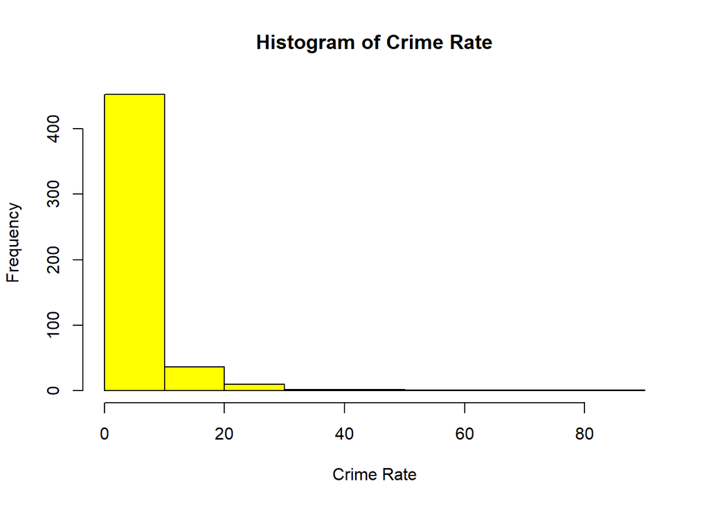

```r
hist(boston.df$CRIM, xlab = "Crime Rate", main = 'Histogram of Crime Rate', col = 'yellow')
```

Box Plot of Crime rate

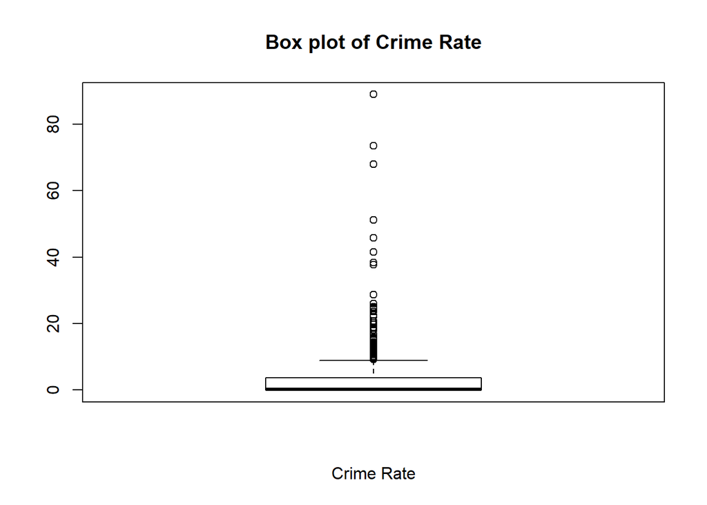

```r
boxplot(boston.df$CRIM, xlab = "Crime Rate", main = 'Box plot of Crime Rate')
```

Plotting ‘MEDV:Median value of owner-occupied homes in $1000s’

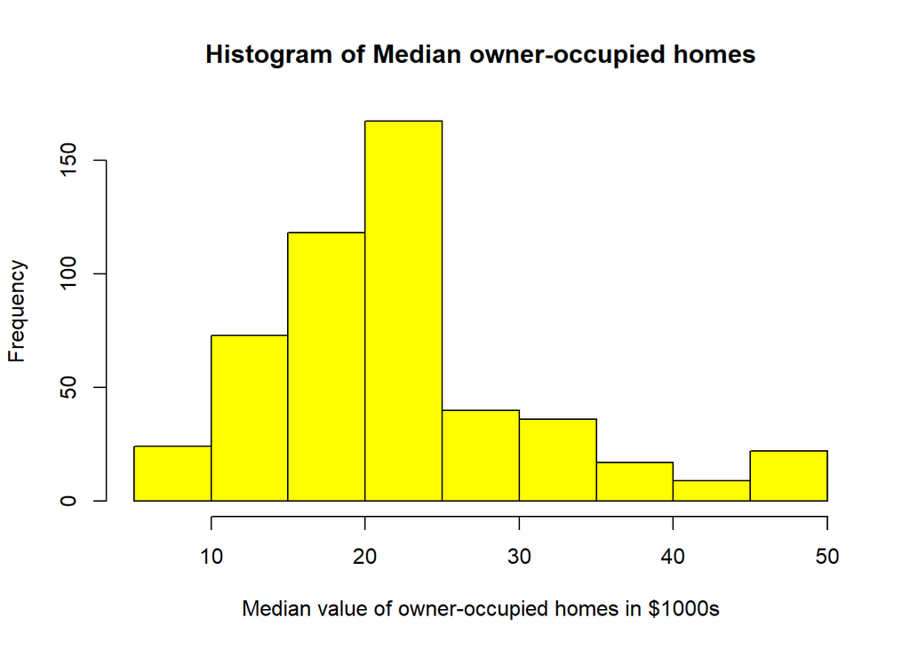

```r
hist(boston.df$MEDV, xlab='Median value of owner-occupied homes in $1000s', main = 'Histogram of Median owner-occupied homes', col='yellow')
```

Boxplot between ‘CRIM:Crime rate’ and ‘MEDV:Median value of owner-occupied homes in $1000s’

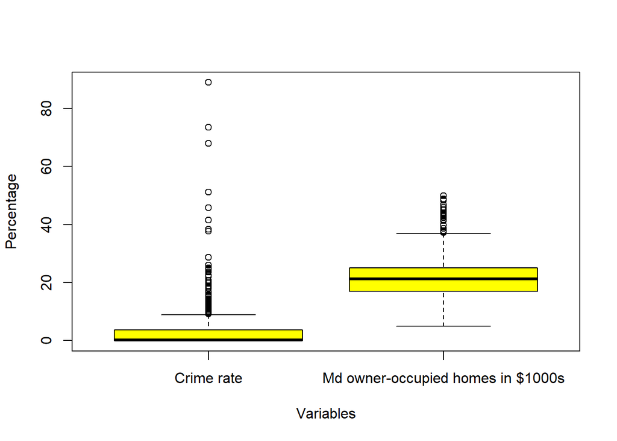

```r
boxplot(boston.df$CRIM, boston.df$MEDV, names = c('Crime rate', 'Md owner-occupied homes in $1000s'),
        xlab='Variables', ylab='Percentage', col = 'yellow')
```

### Prepare scatter plot and Pearson’s correlation coefficient among AGE and DIS variables

Plotting ‘Percentage of owner-occupied units built prior to 1940’ and ‘Weighted distances to five Boston employment centers’

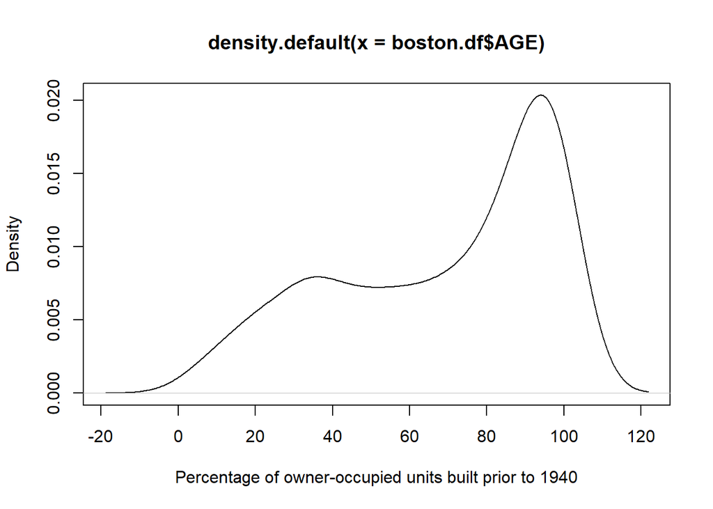

```r
plot(density(boston.df$AGE), xlab = 'Percentage of owner-occupied units built prior to 1940', shade = TRUE)
```

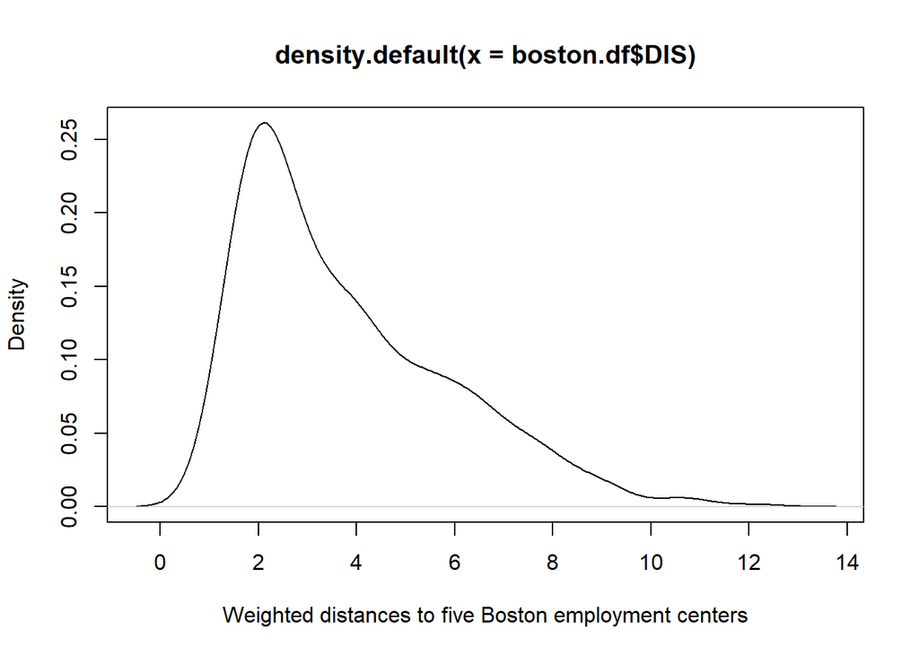

```r
plot(density(boston.df$DIS), xlab='Weighted distances to five Boston employment centers', shade = TRUE)
```

```r
cor(boston.df$DIS, boston.df$AGE)
```

```
## [1] -0.7478805
```

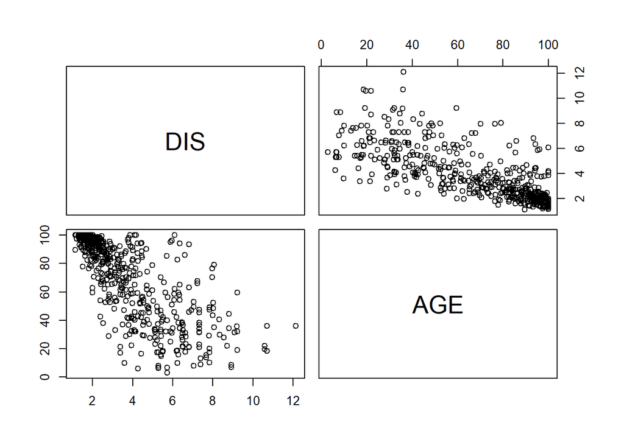

```r
pairs(~DIS+AGE, data=boston.df)
```

## Conclusion

We used R software to read data from CSV file, and analyzed it based on our learning of different visualization graphs to see if there is any correlation between the pair of variables. We could infer some of the points - The relation between age of the building to the proximity to employment centre are inversely related.